# 231B - Section 5

Natalia Garbiras-Díaz

February 24, 2017

```r
rm(list=ls())
#install.packages("sem")
library(sem)
```

```r
library(sem)
set.seed(5000)
```

## Today

- An IV example
- Small sample bias of the IV estimator (Monte Carlo simulation)

# An IV example in the potential outcomes framework

**Generating potential outcomes**

Potential outcomes for compliers

```r
#potential outcome when instrument is 0
r_0_0 <- runif(1000)*10
#Potential outcome when instrument is 1
r_1_1 <- r_0_0 + 2.5

data <- as.data.frame(cbind(r_0_0, r_1_1))
names(data) <- c("r_0_0", "r_1_1")
```

What will be the value of the potential outcomes for never treats when assigned to the treatment group? Why?

What about the potential outcomes for the always treats who get assigned to the control group? Why? What are we assuming?

What is the instrumental variable here?

**Treatment:** For each unit, we need to know their treatment status if they receive the instrument vs. when they don’t.

Let’s first create the treatment indicators as if every unit was a complier. Compliers take the treatment if the instrument is 1, don’t get treated if instrument is 0.

```r
data$t_0 <- rep(0, 1000) # gets control if instrument=0
data$t_1 <- rep(1, 1000) # gets treamtent if instrument=1
```

# Now let’s include 200 never takers and 200 always takers

Never takers NEVER get the treatment, independent of the value of the instrument.

```r
data$t_1[1:200] <- 0 # the first 200 units will be never takers
```

Always takers ALWAYS get the treatment, independent of the value of the instrument.

```r
data$t_0[201:400] <- 1 # units 201 to 400 will be always takers
```

Let’s see the configuration of types:

```r
table(data$t_0, data$t_1)
```

```
##
##       0   1
##   0 200 600
##   1   0 200
```

Now let’s create an indicator for each type

```r
data$complier <- as.numeric(data$t_1==1 & data$t_0==0)
data$always_taker <- as.numeric(data$t_1==1 & data$t_0==1)
data$never_taker <- as.numeric(data$t_1==0 & data$t_0==0)
```

Let’s make the complier average causal effect different from the average causal effect.

```r
data$r_1_1[data$complier] <- data$r_1_1[data$complier] + 1
# What is now the complier causal treatment effect?
```

**Instrument**

```r
data$z <- sample(c(rep(0, 500), rep(1, 500)), 1000, replace=F)
```

**Realized treatment and outcome vectors**

```r
data$t <- ifelse(data$z==1, data$t_1, data$t_0)
data$r <- ifelse(data$t==1, data$r_1_1, data$r_0_0)
```

**What is the true average causal effect?**

```r
ACE <-  mean(data$r_1_1 - data$r_0_0)
ACE
```

```
## [1] 2.501
```

**What is the true complier average causal effect?**

**What is the true complier average causal effect?**

```r
ACE_compliers <- mean(data$r_1_1[data$complier] - data$r_0_0[data$complier])
ACE_compliers
```

```
## [1] 3.5
```

**What is the effect of treatment assignment (i.e., the instrument) on treatment receipt?**

**What is the effect of treatment assignment (i.e., the instrument) on treatment receipt?**

```r
mean(data$t[data$z==1]) - mean(data$t[data$z==0])
```

```
## [1] 0.6
```

```r
lm(data$t ~ data$z)$coefficients
```

```
## (Intercept)      data$z
##        0.21        0.60
```

```r
Z <- cbind(1, data$z)
solve(t(Z)%*%Z) %*% (t(Z)%*%data$t)
```

```
##      [,1]
## [1,] 0.21
## [2,] 0.60
```

Note that here we are using regression, but there is no real regression model. We do this because the $\hat{\beta}$ is algebraically equivalent to the difference in means (as you have shown in PS 3), but this data generating process does not follow a regression model.

**What does intent-to-treat analysis show?**

**What does intent-to-treat analysis show?**

```r
ITT <- mean(data$r[data$z==1])-mean(data$r[data$z==0])
ITT
```

```
## [1] 1.1424
```

```r
lm(data$r ~ data$z)$coefficients
```

```
## (Intercept)      data$z
##    5.579626    1.142400
```

```r
solve(t(Z)%*%Z) %*% (t(Z)%*%data$r)
```

```
##          [,1]
## [1,] 5.579626
## [2,] 1.142400
```

**What about the IV estimate?**

```r
IV <- ITT / (mean(data$t[data$z==1]) - mean(data$t[data$z==0]))
IV
```

```
## [1] 1.904
```

```r
# "By hand"
fit.2a <- lm(data$t ~ data$z)
t_hat <- fit.2a$fitted
fit.2b <- lm(data$r ~ t_hat) #### coefficients ok, but SE WRONG!
fit.2b
```

```
##
## Call:
## lm(formula = data$r ~ t_hat)
##
## Coefficients:
## (Intercept)        t_hat
##       5.180        1.904
```

```r
# With package
summary(tsls(r~t,~z,data=data))
```

```
##
##  2SLS Estimates
##
## Model Formula: r ~ t
##
## Instruments: ~z
##
## Residuals:
##     Min.  1st Qu.   Median     Mean  3rd Qu.     Max.
## -5.17900 -2.59600  0.02448  0.00000  2.52900  5.40000
##
##              Estimate Std. Error  t value   Pr(>|t|)
## (Intercept) 5.1797860  0.1814919 28.54004 < 2.22e-16 ***
## t           1.9040003  0.3067335  6.20734 7.8904e-10 ***
## ---
## Signif. codes:  0 '***' 0.001 '**' 0.01 '*' 0.05 '.' 0.1 ' ' 1
##
## Residual standard error: 2.9099296 on 998 degrees of freedom
```

**Using the hat matrix**

1. The first stage:

In the context of 2SLS, we are projecting T (our “Y”) onto the column space of Z (our instrument) to get as close as we can to T. Using the definition of the OLS fit, we can do this as follows:

$$\underbrace{\hat{T}}_{\text{Predicted T, first stage}} = Z \hat{\beta}_{OLS} = \underbrace{Z(Z'Z)^{-1}Z'}_{\text{ (Hat matrix)}}\overbrace{T}^{\text{Observed T}}$$

```r
hat_t <- Z %*% solve(t(Z)%*%Z) %*% (t(Z)%*%data$t) # This gives us the predicted T (treatment receipt)

# Remember that Z was constructed to have a column of 1s
```

2. Second stage: regress Y on $\hat{T}$:

```r
HAT_t <- cbind(1, hat_t) # We create our new design matrix

solve( t( HAT_t ) %*% HAT_t ) %*% ( t( HAT_t ) %*% data$r )
```

```
##          [,1]
## [1,] 5.179786
## [2,] 1.904000
```

**What is the difference between the IV estimate and the CACE?**

```r
difference <- IV - ACE_compliers
difference
```

```
## [1] -1.596
```

## Small sample bias of the IV estimator

Now let’s put the intuition of what we have done above into programming a simulation that shows that the IV estimator is biased but consistent.

Would we do this differently if we used the Neyman model vs a regression model? If so, what would be the difference between these simulations?

We will use the population we created above, but instead of using a fixed number of units, we will sample from it to vary N.

How do we write a simulation that runs experiments of different sizes and calculates the `ACE_compliers` and the sampling distribution of the `IV` estimator for each?

```r
N <- seq(50, 5000, by=100)

ACE_compliers <- NULL
IV <- NULL

for (i in 1:length(N)){

    # we reuse data so that we dont need to build the dataset each time.
    sim_data <- data[sample(1:nrow(data), N[i], replace=T), ]

    ACE_compliers[i] <- mean(sim_data$r_1_1[sim_data$complier]) - mean(sim_data$r_0_0[sim_data$complier])

    ### some simulation that repeats sampling many times with this dataset fixed
    ## returns a vector with IV estimates


}
```

```r
experiment <- function(sim_data){

  z <- sample(sim_data$z, nrow(sim_data), replace=F)

  t <- ifelse(z==1, sim_data$t_1, sim_data$t_0)
  r <- ifelse(t==1, sim_data$r_1_1, sim_data$r_0_0)

  ITT <- mean(r[z==1]) - mean(r[z==0])

  IV <- ITT / (mean(t[z==1]) - mean(t[z==0]))

  return(IV)

}
```

We want to replicate this several times varying N

```r
N <- seq(50, 2000, by=25)

ACE_compliers <- NULL
IV <- matrix(NA, length(N), 10000)

for (i in 1:length(N)){

    # we reuse data so that we dont need to build the dataset each time.
    sim_data <- data[sample(1:nrow(data), N[i], replace=T), ]

    ### some simulation that repeats sampling many times with this dataset fixed
    ## returns a vector with IV estimates
    IV[i,] <- replicate(10000, experiment(sim_data))


}
```

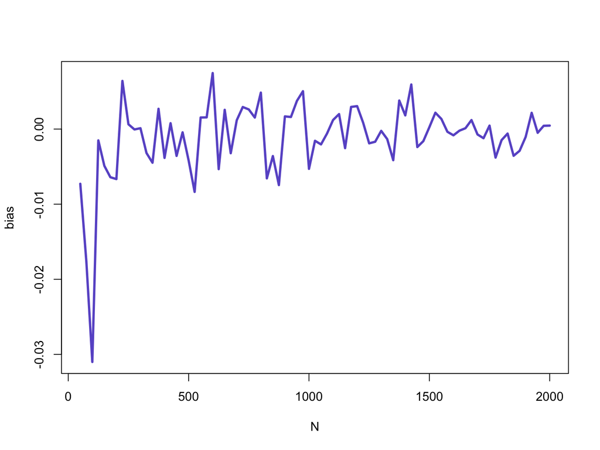

```r
IV_mean <- apply(IV, 1, mean)
bias <- IV_mean - 2.5 #ACE for compliers

plot(N, bias, type="l", col="slateblue", lwd=3)
```

- Notice that the bias seems substantively very small